# exploration_template

## Project : Ford GoBike Data Exploration

### Introductory Wrangling:

**Discover Dataset:**

```python
import numpy as np
import pandas as pd
import matplotlib.pyplot as plt
import seaborn as sb

%matplotlib inline
```

```python
df = pd.read_csv('201902-fordgobike-tripdata.csv')
df.head()
```

|  | duration_sec | start_time | end_time | start_station_id | start_station_name | start_station_latitude | start_station_longitude | end_station_id | end_station_name | end_station_latitude | end_station_longitude | bike_id | user_type | member_birth_year | member_gender | bike_share_for_all_trip |
| --- | --- | --- | --- | --- | --- | --- | --- | --- | --- | --- | --- | --- | --- | --- | --- | --- |
| 0 | 52185 | 2019-02-28 17:32:10.1450 | 2019-03-01 08:01:55.9750 | 21.0 | Montgomery St BART Station (Market St at 2nd St) | 37.789625 | -122.400811 | 13.0 | Commercial St at Montgomery St | 37.794231 | -122.402923 | 4902 | Customer | 1984.0 | Male | No |
| 1 | 42521 | 2019-02-28 18:53:21.7890 | 2019-03-01 06:42:03.0560 | 23.0 | The Embarcadero at Steuart St | 37.791464 | -122.391034 | 81.0 | Berry St at 4th St | 37.775880 | -122.393170 | 2535 | Customer | NaN | NaN | No |
| 2 | 61854 | 2019-02-28 12:13:13.2180 | 2019-03-01 05:24:08.1460 | 86.0 | Market St at Dolores St | 37.769305 | -122.426826 | 3.0 | Powell St BART Station (Market St at 4th St) | 37.786375 | -122.404904 | 5905 | Customer | 1972.0 | Male | No |
| 3 | 36490 | 2019-02-28 17:54:26.0100 | 2019-03-01 04:02:36.8420 | 375.0 | Grove St at Masonic Ave | 37.774836 | -122.446546 | 70.0 | Central Ave at Fell St | 37.773311 | -122.444293 | 6638 | Subscriber | 1989.0 | Other | No |
| 4 | 1585 | 2019-02-28 23:54:18.5490 | 2019-03-01 00:20:44.0740 | 7.0 | Frank H Ogawa Plaza | 37.804562 | -122.271738 | 222.0 | 10th Ave at E 15th St | 37.792714 | -122.248780 | 4898 | Subscriber | 1974.0 | Male | Yes |

```python
df.shape
```

```
(183412, 16)
```

```python
df.info()
```

```
<class 'pandas.core.frame.DataFrame'>
RangeIndex: 183412 entries, 0 to 183411
Data columns (total 16 columns):
 #   Column                   Non-Null Count   Dtype
---  ------                   --------------   -----
 0   duration_sec             183412 non-null  int64
 1   start_time               183412 non-null  object
 2   end_time                 183412 non-null  object
 3   start_station_id         183215 non-null  float64
 4   start_station_name       183215 non-null  object
 5   start_station_latitude   183412 non-null  float64
 6   start_station_longitude  183412 non-null  float64
 7   end_station_id           183215 non-null  float64
 8   end_station_name         183215 non-null  object
 9   end_station_latitude     183412 non-null  float64
 10  end_station_longitude    183412 non-null  float64
 11  bike_id                  183412 non-null  int64
 12  user_type                183412 non-null  object
 13  member_birth_year        175147 non-null  float64
 14  member_gender            175147 non-null  object
 15  bike_share_for_all_trip  183412 non-null  object
dtypes: float64(7), int64(2), object(7)
memory usage: 22.4+ MB
```

**Change start_time and end_time from object to datetime:**

```python
df['start_time'] = pd.to_datetime(df['start_time'])
df['end_time'] = pd.to_datetime(df['end_time'])
```

**Change user_type from object to category:**

```python
df['user_type'] = df.user_type.astype('category')
```

```python
df.dtypes
```

```
duration_sec                        int64
start_time                 datetime64[ns]
end_time                   datetime64[ns]
start_station_id                  float64
start_station_name                 object
start_station_latitude            float64
start_station_longitude           float64
end_station_id                    float64
end_station_name                   object
end_station_latitude              float64
end_station_longitude             float64
bike_id                             int64
user_type                        category
member_birth_year                 float64
member_gender                      object
bike_share_for_all_trip            object
dtype: object
```

### What are the most interesting features in this dataset?

**I am interested in finding out what features are best for predicting the fastest way to end the race.**

### What features do you think will help support your investigation?

**I think the duration_sec,start_station_latitude, start_station_longitude, end_station_latitude, end_station_longitude, start_station_name and, user_type**

## Univariate Exploration:

**distrubtion of duration per second:**

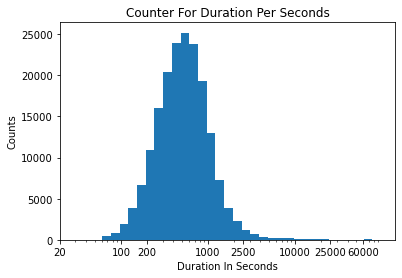

```python
bin_edegs = 10 ** np.arange(1.785, 4.936+0.1, 0.1)
ticks = [20,100,200,1000,2500,10000,25000, 60000]
labels = ['{}' .format(v) for v in ticks]
plt.hist(data = df, x = 'duration_sec' , bins = bin_edegs);
plt.xscale('log');
plt.xticks(ticks,labels);
plt.title('Counter For Duration Per Seconds');
plt.xlabel('Duration In Seconds');
plt.ylabel('Counts');
```

**Most of the racers have finished the race in between 200 Seconds to 1000 Seconds. But, there are outliers in this distribution.**

**Remove the outliers in duration_sec variable that is under 100 seconds and above 2500 seconds:**

```python
df.drop(df[df.duration_sec > 2500].index, inplace=True)
df.drop(df[df.duration_sec < 100].index, inplace=True)
```

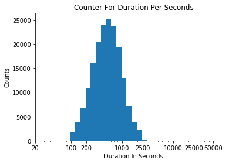

```python
bin_edegs = 10 ** np.arange(1.785, 4.936+0.1, 0.1)
ticks = [20,100,200,1000,2500,10000,25000, 60000]
labels = ['{}' .format(v) for v in ticks]
plt.hist(data = df, x = 'duration_sec' , bins = bin_edegs);
plt.xscale('log');
plt.xticks(ticks,labels);
plt.title('Counter For Duration Per Seconds');
plt.xlabel('Duration In Seconds');
plt.ylabel('Counts');
```

**More accurate to do analysis**

**I will go through the start_station_latitude and end_station_latitude as will as start_station_longitude and end_station_longitude to see what is the difference between them, and if there is any outliers**

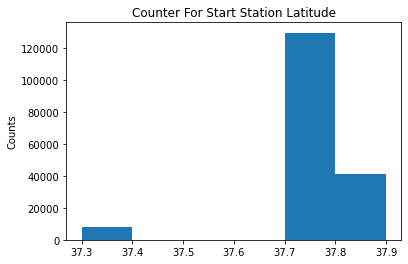

```python
ticks = [37.3,37.4,37.5,37.6,37.7,37.7,37.8,37.9,]
plt.hist(data = df, x = 'start_station_latitude', bins = ticks);
plt.title('Counter For Start Station Latitude');
plt.ylabel('Counts');
```

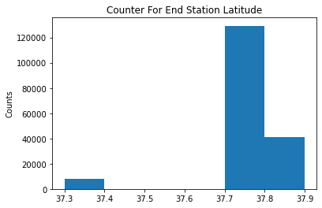

```python
ticks = [37.3,37.4,37.5,37.6,37.7,37.7,37.8,37.9,]
plt.hist(data = df, x = 'end_station_latitude', bins = ticks);
plt.title('Counter For End Station Latitude');
plt.ylabel('Counts');
```

**It is the same for the start/end_station_latitude and the most frequent latitude is between 37.7 and 37.8**

**Rows in start_station_latitude that have less than 37.7 will be removed:**

```python
df.drop(df[df.start_station_latitude < 37.7].index, inplace=True)
```

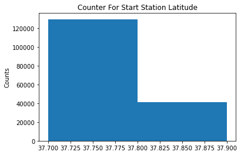

```python
ticks = [37.7,37.8,37.9]
plt.hist(data = df, x = 'start_station_latitude', bins = ticks);
plt.title('Counter For Start Station Latitude');
plt.ylabel('Counts');
```

**Rows in end_station_latitude that have less than 37.7 will be removed:**

```python
df.drop(df[df.end_station_latitude < 37.7].index, inplace=True)
```

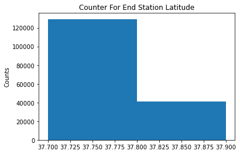

```python
ticks = [37.7,37.8,37.9]
plt.hist(data = df, x = 'end_station_latitude', bins = ticks);
plt.title('Counter For End Station Latitude');
plt.ylabel('Counts');
```

**After i removed outliers from the end and start station latitude the distrbution looks more accurate**

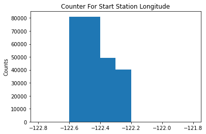

```python
List = [-122.8,-122.6,-122.4,-122.3,-122.2,-122.1,-122.0,-121.9,-121.8]
plt.hist(data = df, x = 'start_station_longitude', bins = List);
plt.title('Counter For Start Station Longitude');
plt.ylabel('Counts');
```

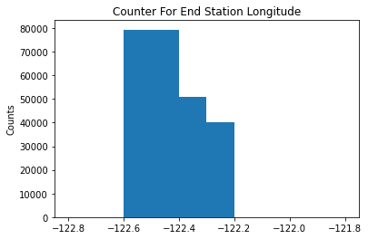

```python
plt.hist(data = df, x = 'end_station_longitude', bins = List );
plt.title('Counter For End Station Longitude');
plt.ylabel('Counts');
```

**Rows that have more than or equal -122.0 will be removed:**

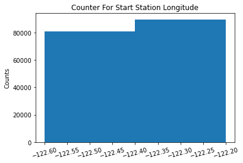

```python
List = [-122.6,-122.4,-122.2]
plt.hist(data = df, x = 'start_station_longitude', bins = List);
plt.title('Counter For Start Station Longitude');
plt.ylabel('Counts');
plt.xticks(rotation = 15);
```

**Rows that have more than or equal -122.0 will be removed**

```python
df.drop(df[df.end_station_longitude >= -122.0].index, inplace=True)
```

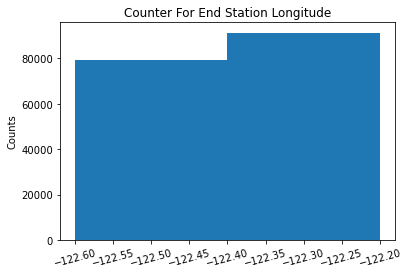

```python
List = [-122.6,-122.4,-122.2]
plt.hist(data = df, x = 'end_station_longitude', bins = List);
plt.title('Counter For End Station Longitude');
plt.ylabel('Counts');
plt.xticks(rotation = 15);
```

**After i have removed the outliers from the end and start station latitude the distrbution looks more accurate**

**I will go through the user_type variable, which is categorical variable and should be plotted in bar chart:**

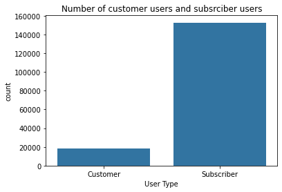

```python
df_color = sb.color_palette()[0]
sb.countplot(data = df, x = 'user_type', color = df_color);
plt.xlabel('User Type');
plt.title('Number of customer users and subsrciber users');
```

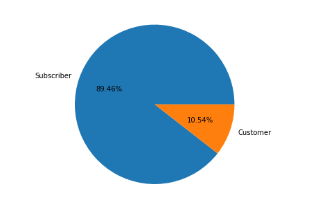

```python
fig = plt.figure()
ax = fig.add_axes([0,0,1,1])
ax.axis('equal')
langs = ['Subscriber', 'Customer']
ax.pie(df.user_type.value_counts(), labels = langs,autopct='%1.2f%%');
plt.show();
```

**I compared two type of users: Subscriber and Customer, in this dataset we have more than 140000 subsrcibers with 89.46% and almost 20000 customers with 10.54%.**

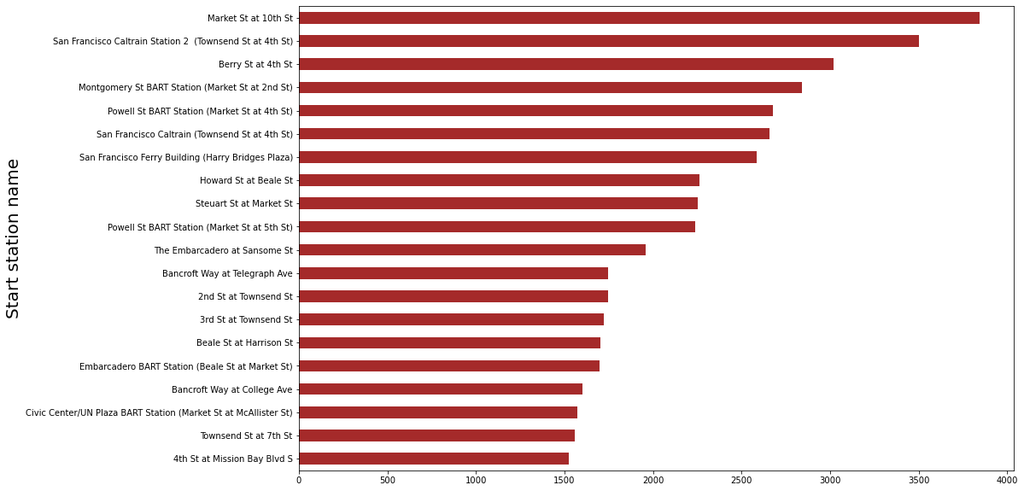

```python
plt.figure(figsize=[15, 10]);
df['start_station_name'].value_counts().sort_values().tail(20).plot(kind='barh', color = 'brown');
plt.ylabel('Start station name',fontsize=20);
```

**Most racers start at Market St at 10th St**

### Discuss the distributions of your variables of interest. Were there any unusual points? Did you need to perform any transformations?

**The duration per second variable took on a huge range of values, so I looked at the data using a log transform. Under the transformation, the data looked unimodal. Most of the users are Subscribers.**

### The features you investigated, were there any unusual distributions? Did you perform any operations on the data to tidy, adjust, or change the form of the data? If so, why did you do this?

**When investigating the duration per second, the both two station latitude, and the both two station longitude variables, a number of outlier points were identified. For safety, all of these points were removed from the dataset to move forwards.**

## Bivariate Exploration:

**relationship between duration_sec and user_type using violing plot:**

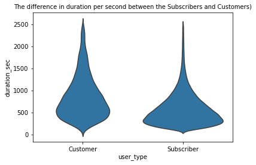

```python
sb.violinplot(data = df, x = 'user_type', y = 'duration_sec',color = df_color, inner = None);
plt.title('The difference in duration per second between the Subscribers and Customers)', size = 10);
```

**It is looks like the Subscribers often finish the race faster than the Customers.**

**I will take look at the relationship between duration_sec and start_station_latitude, duration_sec and end_station_latitude using scatter plot:**

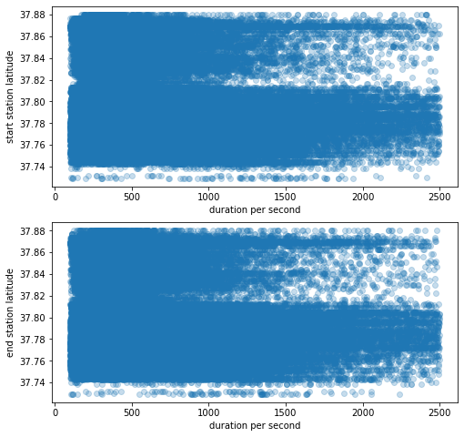

```python
plt.figure(figsize= [8,8])
plt.subplot(2, 1, 1)
plt.scatter(data = df, x = 'duration_sec', y = 'start_station_latitude', color = df_color,alpha = 1/4)
plt.xlabel('duration per second')
plt.ylabel('start station latitude')
plt.subplot(2, 1, 2)
plt.scatter(data = df, x = 'duration_sec', y = 'end_station_latitude' ,color = df_color,alpha = 1/4)
plt.xlabel('duration per second')
plt.ylabel('end station latitude')
plt.show()
```

**I will take look at the relationship between (duration_sec) and (start_station_longitude), (duration_sec) and (end_station_longitude) using scatter plot:**

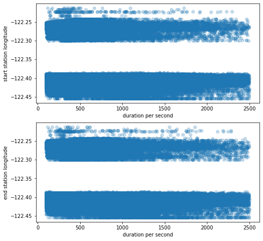

```python
plt.figure(figsize= [8,8])
plt.subplot(2, 1, 1)
plt.scatter(data = df, x = 'duration_sec', y = 'start_station_longitude', color = df_color, alpha = 1/4)
plt.xlabel('duration per second')
plt.ylabel('start station longitude')
plt.subplot(2, 1, 2)
plt.scatter(data = df, x = 'duration_sec', y = 'end_station_longitude' ,color = df_color, alpha = 1/4)
plt.xlabel('duration per second')
plt.ylabel('end station longitude')
plt.show()
```

**I will take look at the relationship between start_station_latitude and start_station_longitude, end_station_latitude and end_station_longitude using scatter plot.**

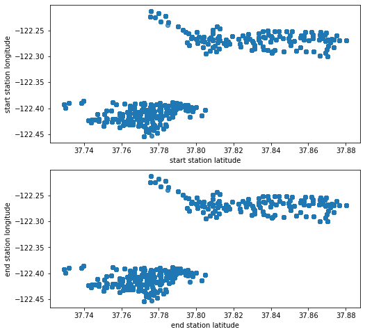

```python
plt.figure(figsize= [8,8])
plt.subplot(2, 1, 1)
plt.scatter(data = df, x = 'start_station_latitude', y = 'start_station_longitude', color = df_color, alpha = 1/4)
plt.xlabel('start station latitude')
plt.ylabel('start station longitude')
plt.subplot(2, 1, 2)
plt.scatter(data = df, x = 'end_station_latitude', y = 'end_station_longitude' ,color = df_color, alpha = 1/4)
plt.xlabel('end station latitude')
plt.ylabel('end station longitude')
plt.show()
```

**The scatter plot shows that the most frequent latitude and longitude is between (37.76) and (37.80) for the latitude, (-122.45) and (-122.40) for the longitude.**

## Did you observe any interesting relationships between the other features (not the main features of interest)?

**The most frequent longitude and latitude is between 37.76 and 37.80 for the latitude, -122.45 and -122.40 for the longitude**

## Multivariate Exploration:

**I will look at the relationship between duration_sec, start_station_longitude, and user_type, then i will look the relationship between duration_sec, start_station_latitude, and user_type. In both plots i will use point plot with Non-Positional Encoding.**

**I will create new variable in our dataframe that containts the (duration per minute), but I will get rid of the fractions, so the accuracy maybe will be less, but the plot will become more interpetable:**

```python
## convert seconds to minutes
df['duration_min'] = df['duration_sec'] // 60
df.head()
```

|  | duration_sec | start_time | end_time | start_station_id | start_station_name | start_station_latitude | start_station_longitude | end_station_id | end_station_name | end_station_latitude | end_station_longitude | bike_id | user_type | member_birth_year | member_gender | bike_share_for_all_trip | duration_min |
| --- | --- | --- | --- | --- | --- | --- | --- | --- | --- | --- | --- | --- | --- | --- | --- | --- | --- |
| 4 | 1585 | 2019-02-28 23:54:18.549 | 2019-03-01 00:20:44.074 | 7.0 | Frank H Ogawa Plaza | 37.804562 | -122.271738 | 222.0 | 10th Ave at E 15th St | 37.792714 | -122.248780 | 4898 | Subscriber | 1974.0 | Male | Yes | 26 |
| 5 | 1793 | 2019-02-28 23:49:58.632 | 2019-03-01 00:19:51.760 | 93.0 | 4th St at Mission Bay Blvd S | 37.770407 | -122.391198 | 323.0 | Broadway at Kearny | 37.798014 | -122.405950 | 5200 | Subscriber | 1959.0 | Male | No | 29 |
| 7 | 1615 | 2019-02-28 23:41:06.766 | 2019-03-01 00:08:02.756 | 10.0 | Washington St at Kearny St | 37.795393 | -122.404770 | 127.0 | Valencia St at 21st St | 37.756708 | -122.421025 | 6329 | Subscriber | 1989.0 | Male | No | 26 |
| 8 | 1570 | 2019-02-28 23:41:48.790 | 2019-03-01 00:07:59.715 | 10.0 | Washington St at Kearny St | 37.795393 | -122.404770 | 127.0 | Valencia St at 21st St | 37.756708 | -122.421025 | 6548 | Subscriber | 1988.0 | Other | No | 26 |
| 9 | 1049 | 2019-02-28 23:49:47.699 | 2019-03-01 00:07:17.025 | 19.0 | Post St at Kearny St | 37.788975 | -122.403452 | 121.0 | Mission Playground | 37.759210 | -122.421339 | 6488 | Subscriber | 1992.0 | Male | No | 17 |

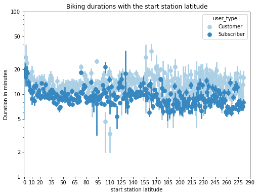

```python
fig = plt.figure(figsize = [8,6]);
ax = sb.pointplot(data = df, x = 'start_station_latitude', y = 'duration_min', hue = 'user_type',
           palette = 'Blues', linestyles = '');
plt.title('Biking durations with the start station latitude')
plt.xlabel('start station latitude')
plt.ylabel('Duration in minutes')
plt.yscale('log')
plt.yticks([1, 2, 5, 10, 20, 50, 100], [1, 2, 5, 10, 20, 50, 100]);
plt.xticks([0,10,20,35,50,65,80,95,110,125,140,155,170,185,200,215,230,245,260,275,290],[0,10,20,35,50,65,80,95,110,125,140,155,170,185,200,215,230,245,260,275,290]);
ax.set_yticklabels([],minor = True);
```

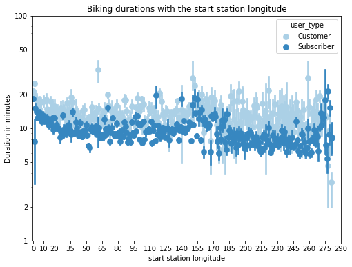

```python
fig = plt.figure(figsize = [8,6]);
ax = sb.pointplot(data = df, x = 'start_station_longitude', y = 'duration_min', hue = 'user_type',
           palette = 'Blues', linestyles = '');
plt.title('Biking durations with the start station longitude')
plt.xlabel('start station longitude')
plt.ylabel('Duration in minutes')
plt.yscale('log')
plt.yticks([1, 2, 5, 10, 20, 50, 100], [1, 2, 5, 10, 20, 50, 100]);
plt.xticks([0,10,20,35,50,65,80,95,110,125,140,155,170,185,200,215,230,245,260,275,290],[0,10,20,35,50,65,80,95,110,125,140,155,170,185,200,215,230,245,260,275,290]);
ax.set_yticklabels([],minor = True);
```

## Talk about some of the relationships you observed in this part of the investigation. Were there features that strengthened each other in terms of looking at your features of interest?

**I extended my investigation further more with the the duration and the user type and the longitude and latitude, the plots shows that the Subscribers user type is faster than the Customers user type.**

```python
df.to_csv('df_file.csv', index=False)
```

## Refrences:

**https://matplotlib.org/3.2.1/api/_as_gen/matplotlib.pyplot.xticks.html**

**https://seaborn.pydata.org/generated/seaborn.violinplot.html**

**https://www.geeksforgeeks.org/python-program-to-convert-seconds-into-hours-minutes-and-seconds/**